# Pulse programming in TopSpin, part 7

nmr

pulse programming

Published

July 23, 2023

This is a short post, featuring a small exercise designed to consolidate everything we’ve learnt so far.

*(This is part 7 of a series of posts on pulse programming in TopSpin. For the other parts, see the table of contents here.)*

# Perfect echo

Your job here is to implement the following sequence, called a *perfect echo*:

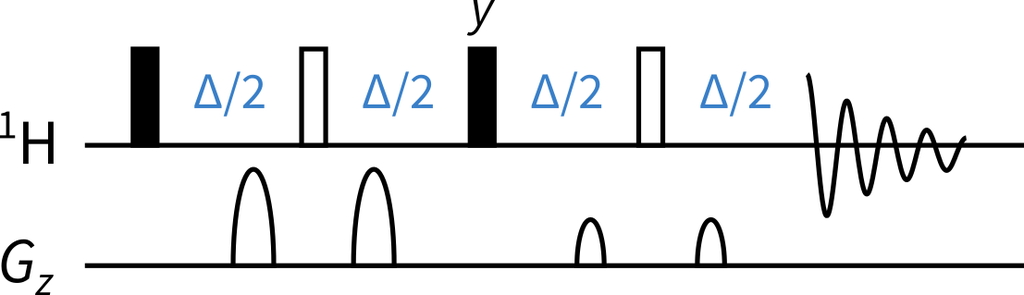

The perfect echo pulse sequence.

In some senses, it’s an “upgrade” on the ordinary spin echo, which refocuses chemical shifts but not J-couplings. The perfect echo refocuses *both* chemical shifts as well as J-couplings, and indeed has been directly dropped into some pulse sequences in place of a spin echo whenever it’s important that J-modulation be removed or decreased.[^1]

(Again, this is a good place to apply some theory. Analyse the perfect echo sequence using product operators. Specifically, show that J-couplings are refocused for a two-spin IS system: start with $\hat{I}_z + \hat{S}_z$ and show that at the end we get $-\hat{I}_y - \hat{S}_y$.)

We have covered enough ground in the previous posts that you should be able to write this yourself. In fact, the spin echo sequence at the end of the previous post is a good starting point. Good luck! Here are a few pointers:

- All unspecified phases are along $+x$. You can ignore phase cycling for now. However, you will still need to define at least two different phases, for example `ph1` and `ph2`.
- It’s OK to use the same gradient duration for each, but the amplitudes should be different. This is important because we don’t want the second pair of gradients to accidentally refocus coherences that were dephased earlier by the first pair.
- We should allow the user to enter $\Delta$ (and not make them calculate $\Delta/2$ themselves) in the `ased` screen. Your pulse programme should automatically halve this as necessary. Note that you should also include compensation for the `p16 + d16`, as discussed in the previous post.

*No solutions are provided!* You should check your pulse programme with somebody experienced, such as your supervisor, or somebody else in your group. If you’re worried, run it past somebody *before* actually running the experiment.

When you’re done, run the experiment. You should find that the multiplets are now no longer distorted, or are at least significantly less distorted. These are the results I got (the original spin echo is on the bottom, and the perfect echo on top):

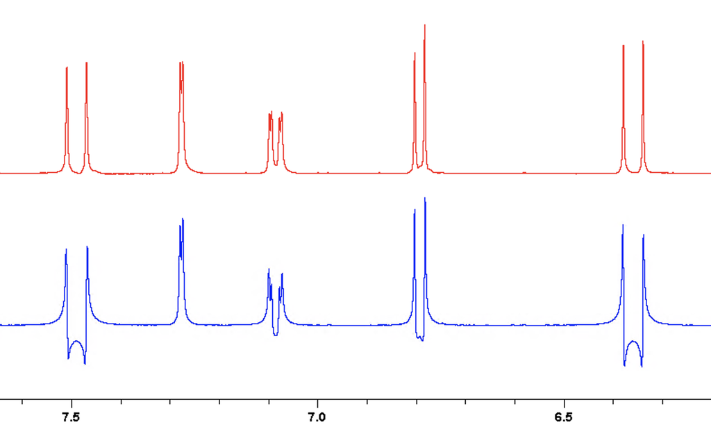

Spectra from spin echo (bottom) and perfect echo (top) experiments.

## Footnotes

[^1]: (More advanced topics.) This idea of refocusing J-coupling seems to suggest that the perfect echo can be used as an element for *pure shift* NMR. However, this is not actually possible. The reason is because the perfect echo doesn’t *just* refocus J-couplings; it *also* causes coherence transfer between both spins. That is to say, any magnetisation that was on spin $I$ in the first half of the perfect echo ends up on spin $S$ in the second half, and vice versa. In contrast, pure shift elements like the PSYCHE double chirp refocus J-couplings *without* causing coherence transfer. (The fact that the perfect echo causes coherence transfers is not necessarily a bad thing: it has been used to great effect in the CLIP-COSY and other related sequences.)